# Math 1115 Group Project

Project 1

510568177 and 510549969

University of Sydney | Math1115 | Sep 2021

# Executive Summary

- The aim of this report is to find relationship between different variables and represent these results to the comunity of league of legend gamers.
- The main discoveries are the listed several that:
- no clear relationship between the amount of Ward placed and player death
- clear relationship show that the higher number of enemies killed leads to higher total gold earned by blue team.
- clear relationship that the lower death people get in game, the higher chance of the team winning the present gameplay.
- clear relationship shows that the more cs the blue team have, the higher level or higher experience would get in total.

# Full Report

## Research Question 1

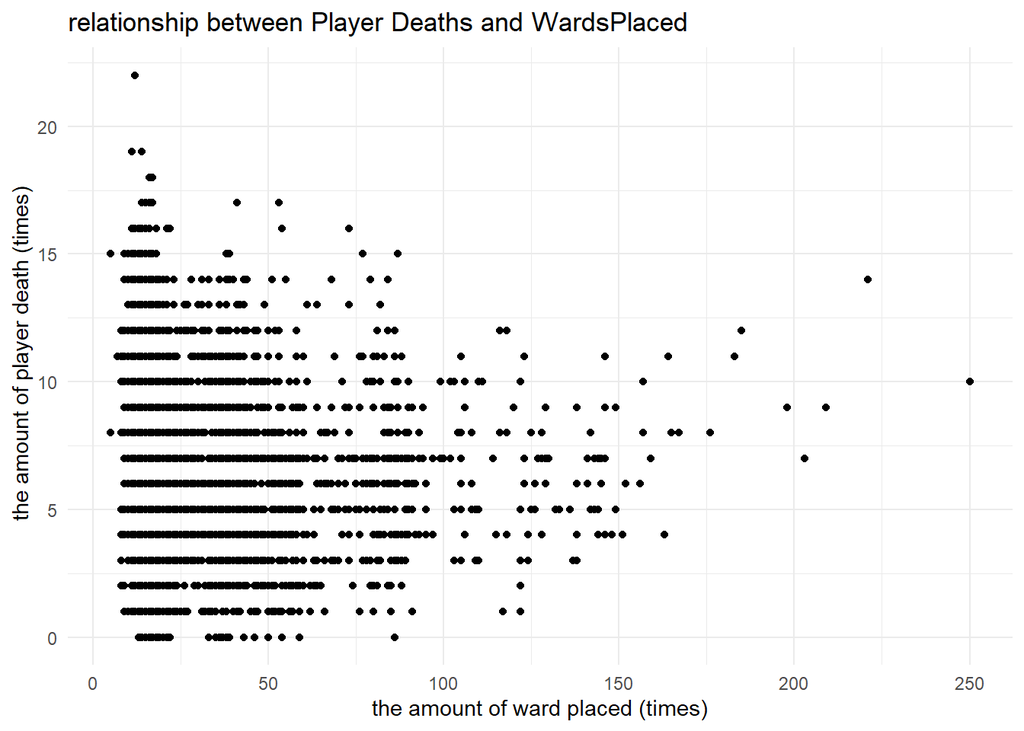

```r
lol1 %>%
  dplyr::select(blueWardsPlaced, blueDeaths) %>%
  ggplot(aes(x = blueWardsPlaced, y = blueDeaths)) +
  geom_point() +
  xlab("the amount of ward placed (times)") +
  ylab(" the amount of player death (times)") +
  ggtitle ("relationship between Player Deaths and WardsPlaced") +
  theme_minimal() +
  geom_blank()
```

I wonder whats the relationship between blueteam’s WardsPlaced and Deaths in League of Legend Diamond and higher ranks.

Analysis:

As the graph shown, we has an x-value of wardsplaces and y-value of player’s death, in which as we known, in League of Legend, the more wards you placed, the more vision you can get. So i wonder if there’s a relationship that placing ward to get more vision can avoid from possible death in gameplay. The data points in the graph are spreading equally into several lines, which we can find that due to x-value of the amount of wards places, most of the gameplay will place a ward number of 0- 50 per game in which due to dataset, these are mostly diamond and lower dimand ranks, the graph doesnt represent a clear relationship between the the amount of ward places and the amount of player death. as player death has a huge float between 0 to 20, and further in the larger amount of ward placed, theres still lot amount of player death, but mainly between 3 death to 10 death per game, which means that no clear relationship between these two varibales, and the player death’s amount might have a further clear relationship with other values instead of ward placed.

## Research Question 2

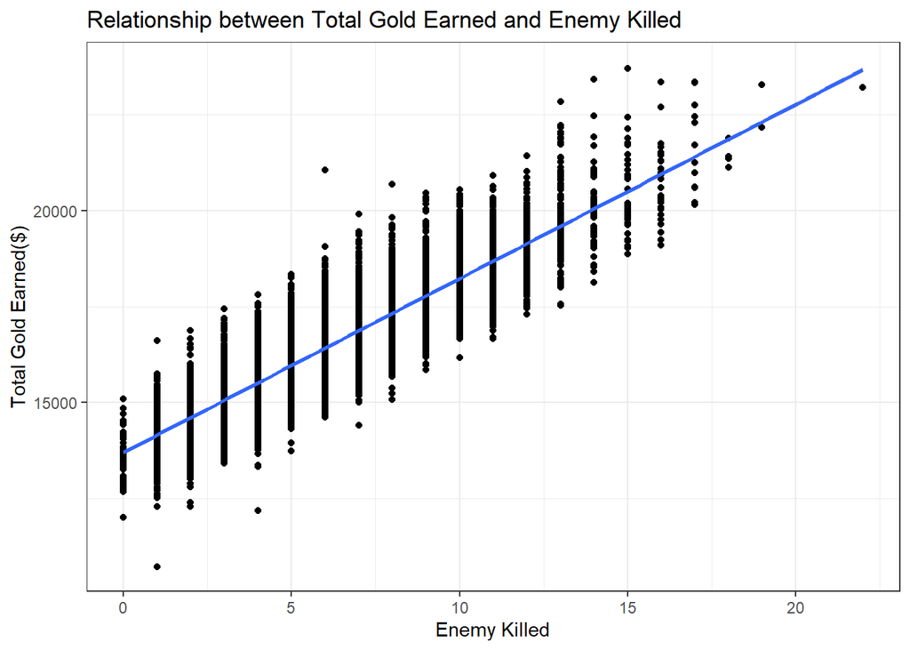

```r
lol1 %>%
  select(blueKills, blueTotalGold) %>%
  ggplot(aes(x=blueKills, y=blueTotalGold)) +
  geom_point() +
  geom_smooth(method = "lm") +
  xlab ("Enemy Killed") +
  ylab("Total Gold Earned($)") +
  ggtitle("Relationship between Total Gold Earned and Enemy Killed") +
  theme_bw() +
  geom_blank()
```

In this dataset, I am trying figure out whether bluekills would affect the bluetotalgold in League of Lengend

## Research Question 3

```
## No summary function supplied, defaulting to `mean_se()`
```

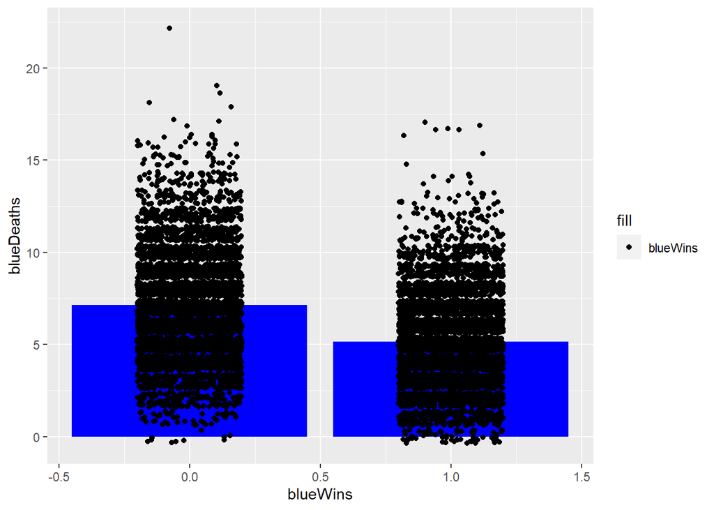

```r
lol1 %>%
  dplyr::select(blueWins, blueDeaths) %>%
  ggplot(aes(blueWins, blueDeaths, fill = "blueWins")) +
    geom_bar(stat = "summary", ,fill = "blue") +
    geom_point(position = position_jitter(0.2))
```

I wonder if there is a the relationship between blueWins and Deaths in League of Legend Diamond and higher ranks.

Analysis: As the graph shown, the amount of player death in blue are mainly between 1 to 10 . As the left bar is blue lost data, the right bar is blue win data. As the bluedeaths between 1 and 10 are equailly seperated in the amount of samples of both win and lose, which means in the amount of death < 10, its likely to say that it’s a fair chance of winning or losing the game.

Later when the player death reaches 12 and more, the blue lost ratio increased comparing to blue wins, which means that we can say there’s some evidence to say the higher death the team reached, the higher chance the team lost the gamer. The blue team’s data can also work on red team as the game randomly drop people into either red or blue. Overall, mainly the game winning player’s death range mean is lower than player’s losts mean of death. So there are clear relationship and some evidence to say that the more death you get, the less chance you can win the game.

## Research Question 4

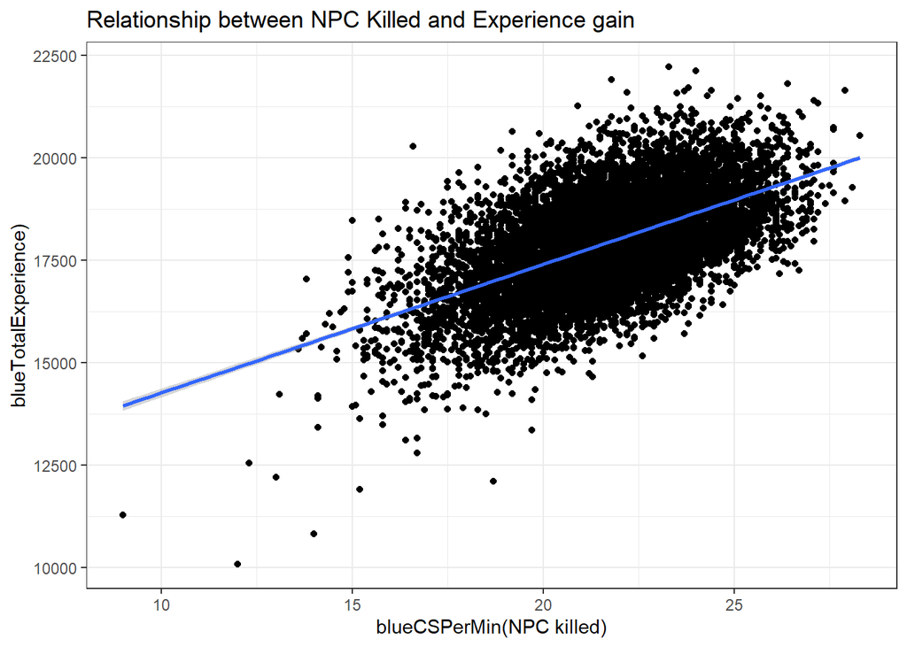

```r
lol1 %>%
  select(blueCSPerMin, blueTotalExperience) %>%
  ggplot(aes(x=blueCSPerMin, y=blueTotalExperience)) +
  geom_point() +
  geom_smooth(method = "lm") +
  xlab ("blueCSPerMin(NPC killed)") +
  ylab("blueTotalExperience)") +
  ggtitle("Relationship between NPC Killed and Experience gain") +
  theme_bw() +
  geom_blank()
```

The purpose of making this data is mainly to discover if there is a relationship between blue cs per min and the blue total experience gain in League of Legend high ELO ranks.

Analysis: Fist, we need to understand the x-axis is BlueCSPerMin which can be known as enemy NPC that belong to red team. They give gold when killed by blue team, in this case it means how many enemy NPC that blue team has killed. The y-axis is blue total Experience, which can be described as an amount that apply to players to leveling up.

As a summary: there are an obvious relationship and evidence show that the higher of blueTotalEXperience is rely on a higher CS per min, in other words, the higher bluecspermin leads to a higher blueTotalExperience. The more cs the blue team have, the higher level or higher experience would get.

## Initial Data Analysis (IDA)

Summary (suggesstion):

- The data came from kaggle website
- The data is valid because kaggle is a trustworth website due to its age and lots of dataset and further community
- Possible issues include dataset’s sampling amounts, accuracy due to collections and so on

# References

> Style: APA https://www.kaggle.com/bobbyscience/league-of-legends-diamond-ranked-games-10-min